# IOOS QARTOD software (ioos_qc)

Mathew Biddle  
mathew.biddle@noaa.gov  
https://orcid.org/0000-0003-4897-1669  
NOAA/NOS/IOOS  
<sub>Materials available at https://github.com/MathewBiddle/WIO_workshop.</sub>

This presentation will demonstrate how to [run `ioos_qc`](https://github.com/ioos/ioos_qc) on a time-series dataset. `ioos_qc` implements the [Quality Assurance / Quality Control of Real Time Oceanographic Data (QARTOD)](https://ioos.noaa.gov/project/qartod/).

### Key Objectives of QARTOD

- Establish authoritative QA/QC procedures for the [U.S. IOOS core variables](http://www.iooc.us/task-teams/core-ioos-variables/), as necessary, including detailed information about the sensors and procedures used to measure the variables.
- Produce written manuals for these QA/QC procedures
- From the list of individual QA/QC procedures and guidelines developed, define a baseline set of QA/QC procedures that can be used for certification of RCOOS data providers
- Facilitate QA/QC integration with Global Ocean Observing System (GOOS) and other international ocean observation efforts
- Engage the Federal Agencies and IOOS Regions that are part of, or contribute to, US IOOS who will use the established QA/QC procedure
- Work efficiently, without duplication of effort, to facilitate the implementation of common QA/QC procedures amongst US IOOS Partners.

## Let's go get these data

We will be using the water level data from a [fixed station in Kotzebue, AK](https://www.google.com/maps?q=66.895035,-162.566752).

[figure not shown]

We will get the data from the [AOOS ERDDAP server](http://erddap.aoos.org/erddap/).

```python
from erddapy import ERDDAP

e = ERDDAP(
    server="http://erddap.aoos.org/erddap/",
    protocol="tabledap"
)

e.dataset_id = "kotzebue-alaska-water-level"

e.constraints = {
    "time>=": "2018-09-05T21:00:00Z",
    "time<=": "2019-07-10T19:00:00Z",
}
```

## Return data and metadata

```python
import cf_xarray
import netCDF4

data = e.to_xarray()

data
```

```
<xarray.Dataset> Size: 1MB
Dimensions:                            (timeseries: 1, obs: 7241)
Coordinates:
    latitude                           (timeseries) float64 8B ...
    longitude                          (timeseries) float64 8B ...
    time                               (obs) datetime64[ns] 58kB ...
Dimensions without coordinates: timeseries, obs
Data variables: (12/21)
    station                            (timeseries) object 8B ...
    rowSize                            (timeseries) int32 4B ...
    water_surface_above_mhw            (obs) float64 58kB ...
    water_surface_above_mhw_qc_agg     (obs) float64 58kB ...
    water_surface_above_mhw_qc_tests   (obs) float64 58kB ...
    water_surface_above_mllw           (obs) float64 58kB ...
    ...                                 ...
    water_surface_above_mtl_qc_agg     (obs) float64 58kB ...
    water_surface_above_mtl_qc_tests   (obs) float64 58kB ...
    z                                  (obs) float64 58kB ...
    water_surface_above_mhhw           (obs) float64 58kB ...
    water_surface_above_mhhw_qc_agg    (obs) float64 58kB ...
    water_surface_above_mhhw_qc_tests  (obs) float64 58kB ...
Attributes: (12/54)
    cdm_data_type:                 TimeSeries
    cdm_timeseries_variables:      station,longitude,latitude
    contributor_email:             dggspubs@alaska.gov,information@aoos.org,,...
    contributor_name:              Alaska Division of Geological & Geophysica...
    contributor_role:              collaborator,sponsor,contributor,processor
    contributor_role_vocabulary:   NERC
    ...                            ...
    station_id:                    100053
    summary:                       Timeseries data from 'Kotzebue, AK (KZTA2)...
    time_coverage_end:             2019-07-10T19:00:00Z
    time_coverage_start:           2018-09-05T21:00:00Z
    title:                         Kotzebue, AK (KZTA2)
    Westernmost_Easting:           -162.566752
```

```python
data.cf
```

```
Discrete Sampling Geometry:
            CF Roles:   timeseries_id: ['station']

Coordinates:
             CF Axes:   X: ['longitude']
                        Y: ['latitude']
                        T: ['time']
                        Z: n/a

      CF Coordinates:   longitude: ['longitude']
                        latitude: ['latitude']
                        time: ['time']
                        vertical: n/a

       Cell Measures:   area, volume: n/a

      Standard Names:   latitude: ['latitude']
                        longitude: ['longitude']
                        time: ['time']

              Bounds:   n/a

       Grid Mappings:   n/a

Data Variables:
       Cell Measures:   area, volume: n/a

      Standard Names:   aggregate_quality_flag: ['water_surface_above_mhhw_qc_agg']
                        altitude: ['z']
                        quality_flag: ['water_surface_above_mhhw_qc_tests']
                        sea_surface_height_above_sea_level: ['water_surface_above_mhhw']

              Bounds:   n/a

       Grid Mappings:   n/a
```

```python
data.cf.axes
```

```
{'X': ['longitude'], 'Y': ['latitude'], 'T': ['time']}
```

```python
data.cf.coordinates
```

```
{'longitude': ['longitude'], 'latitude': ['latitude'], 'time': ['time']}
```

```python
data.cf.standard_names
```

```
{'latitude': ['latitude'],
 'longitude': ['longitude'],
 'time': ['time'],
 'altitude': ['z'],
 'sea_surface_height_above_sea_level': ['water_surface_above_mhhw'],
 'aggregate_quality_flag': ['water_surface_above_mhhw_qc_agg'],
 'quality_flag': ['water_surface_above_mhhw_qc_tests']}
```

## Let's plot the raw data

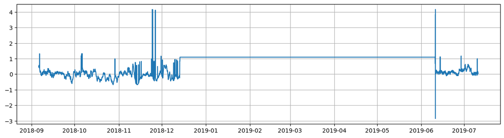

```python
import matplotlib.pyplot as plt

fig, ax = plt.subplots(figsize=(15, 3.75))

ax.plot(data['time'],data['water_surface_above_mhhw'])

ax.grid(True)
```

# Build the QC configuration

Below we create a simple Quality Assurance/Quality Control (QA/QC) configuration that will be used as input for `ioos_qc`. All the interval values are in the same units as the data.

For more information on the tests and recommended values for QA/QC check the documentation of each test and its inputs: https://ioos.github.io/ioos_qc/api/ioos_qc.html#module-ioos_qc.qartod

[Manual for Real-Time Quality Control of Water Level Data](https://cdn.ioos.noaa.gov/media/2021/04/QARTOD_WaterLevelManual_Update_V2.1_Final.pdf)

```python
qc_config = {
    "qartod": {

      "gross_range_test": {
            "suspect_span": [ -2,  3],
            "fail_span":    [-10, 10]
      },

      "flat_line_test": {
            "tolerance":         0.001,
            "suspect_threshold": 10800,
            "fail_threshold":    21600
      },

      "spike_test": {
            "suspect_threshold": 0.8,
            "fail_threshold":      3,
      }
    }
}
```

```python
nice_print(qc_config)
```

```
{
  "qartod": {
    "gross_range_test": {
      "suspect_span": [
        -2,
        3
      ],
      "fail_span": [
        -10,
        10
      ]
    },
    "flat_line_test": {
      "tolerance": 0.001,
      "suspect_threshold": 10800,
      "fail_threshold": 21600
    },
    "spike_test": {
      "suspect_threshold": 0.8,
      "fail_threshold": 3
    }
  }
}
```

# Run the QC tests with the supplied configuration

```python
from ioos_qc.config import QcConfig

qc = QcConfig(qc_config)

variable_name = data.cf.standard_names["sea_surface_height_above_sea_level"][0]

qc_results =  qc.run(
    inp=data[variable_name],
    tinp=data.cf["time"],
)

nice_print(qc_results['qartod'])
```

```
{
  "gross_range_test": "[1 1 1 ... 1 1 1]",
  "flat_line_test": "[1 1 1 ... 1 1 1]",
  "spike_test": "[2 1 1 ... 1 1 2]"
}
```

The results are returned in a dictionary format, similar to the input configuration, with a mask for each test. The results range from 1 to 4 meaning:

| **flag** | **meaning** |
| --- | --- |
| 1 | data passed the QA/QC |
| 2 | did not run on this data point |
| 3 | flag as suspect |
| 4 | flag as failed |

## Let's look at the `gross_range` test results

The gross range test test should fail data outside the $\pm$ 10 range and suspect data below -2, and greater than 3. As one can easily see all the major spikes are flagged as expected.

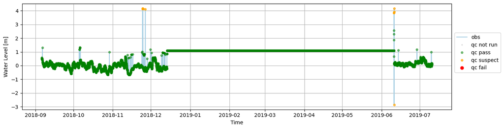

```python
plot_results(
    data,
    variable_name,
    qc_results,
    title,
    "gross_range_test"
)
```

```python
qc_config['qartod']['gross_range_test']
```

```
{'suspect_span': [-2, 3], 'fail_span': [-10, 10]}
```

## Let's look at the `spike` test results

An actual spike test, based on a data increase threshold, flags similar spikes to the gross range test but also indetifies other suspect unusual increases in the series.

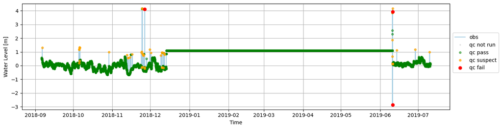

```python
plot_results(
    data,
    variable_name,
    qc_results,
    title,
    "spike_test"
)
```

```python
qc_config['qartod']['spike_test']
```

```
{'suspect_threshold': 0.8, 'fail_threshold': 3}
```

## Let's look at the `flat_line` test results

The flat line test identifies issues with the data where values are "stuck."

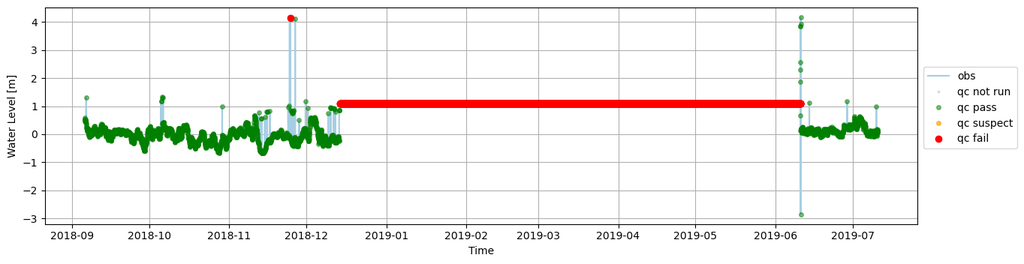

```python
plot_results(
    data,
    variable_name,
    qc_results,
    title,
    "flat_line_test"
)
```

```python
qc_config['qartod']['flat_line_test']
```

```
{'tolerance': 0.001, 'suspect_threshold': 10800, 'fail_threshold': 21600}
```

## What tests are currently available in `ioos_qc` for QARTOD?

```python
import ioos_qc

for func in dir(ioos_qc.qartod):
    if "test" in func:
        print(func)
```

```
attenuated_signal_test
climatology_test
density_inversion_test
flat_line_test
gross_range_test
location_test
rate_of_change_test
spike_test
```

## Where can you find more information?

- IOOS CodeLab example: https://ioos.github.io/ioos_code_lab/content/code_gallery/data_analysis_and_visualization_notebooks/2020-02-14-QARTOD_ioos_qc_Water-Level-Example.html
- Example notebooks: https://github.com/ioos/ioos_qc/tree/master/docs/source/examples
- Source documentation: https://ioos.github.io/ioos_qc/
- QARTOD manuals: https://ioos.noaa.gov/project/qartod/

# Thank you!

Mathew Biddle  
Mathew.Biddle@noaa.gov  
https://orcid.org/0000-0003-4897-1669  
NOAA/NOS/IOOS  
<sub>Materials available at https://github.com/MathewBiddle/WIO_workshop.</sub>